# Assignment 5

#### Chi-Squared Distribution:

$H_0: \mu = \mu_0;\quad H_A: \mu \ne \mu_0.$

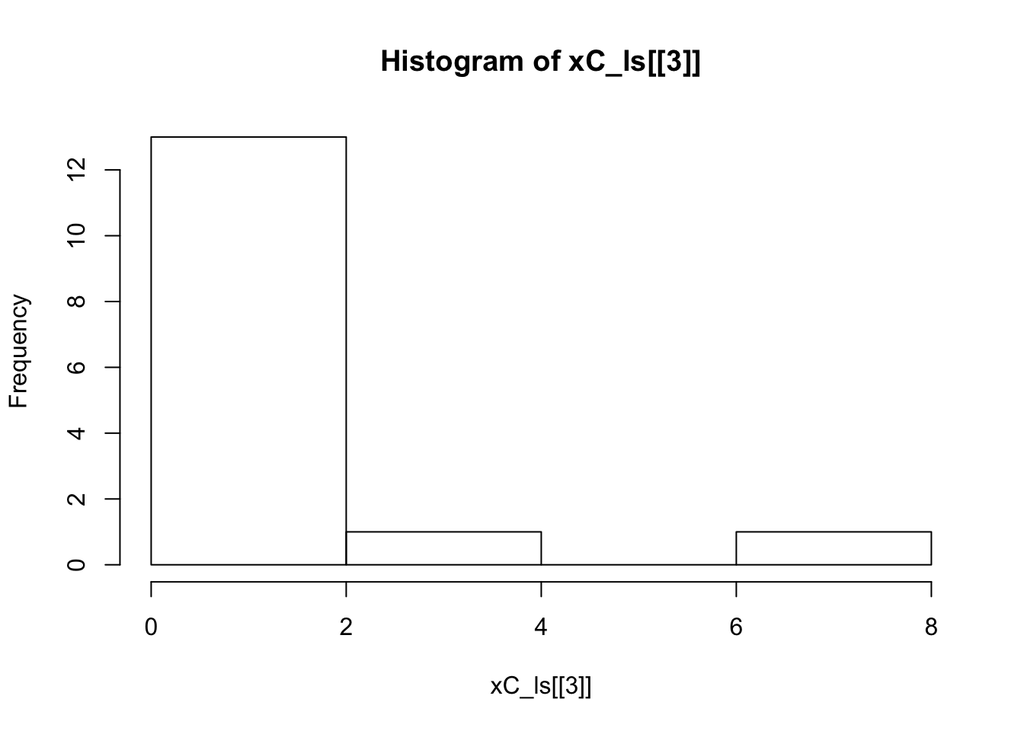

```r
set.seed(1234)
xC_ls <- list(
  dist   = "Chi-Squared",
  params = c(df = 2),
  sample = rchisq(n = 15, df = 2)
)
xC_ls[["histogram"]] <- hist(xC_ls[[3]])
```

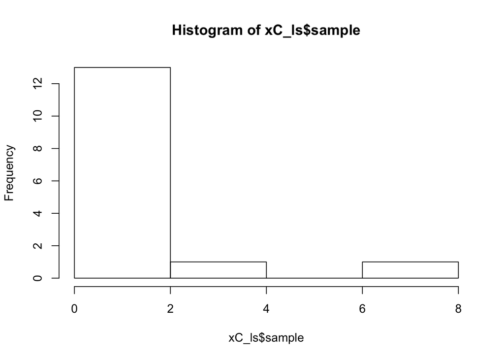

```r
hist(xC_ls$sample)
```

```r
ttest_C <- t.test(
  x = xC_ls$sample,
  alternative = "two.sided",
  mu = xC_ls$params
)
ttest_C$statistic
```

```
##         t
## -1.554084
```

```r
ttest_C$p.value
```

```
##        df
## 0.1424741
```

```r
critVal_C <- qt(0.975, df = 15 - 1)
abs(ttest_C$statistic) > critVal_C
```

```
##     t
## FALSE
```

```r
xC_ls$pVal <- ttest_C$p.value
xC_ls$testStat <- ttest_C$statistic
xC_ls$critVal <- critVal_C
xC_ls$decision <- "Fail to Reject the Hypothesis that the True Mean Equals 2"
xC_ls
```

```
## $dist
## [1] "Chi-Squared"
##
## $params
## df
##  2
##
## $sample
##  [1] 0.02145511 1.49399813 1.57265591 0.23375047 1.84371739 0.35235796
##  [7] 2.87428445 0.31343940 0.43900405 7.05514522 0.12651363 0.29429374
## [13] 1.19861920 0.42645167 1.00709343
##
## $histogram
## $breaks
## [1] 0 2 4 6 8
##
## $counts
## [1] 13  1  0  1
##
## $density
## [1] 0.43333333 0.03333333 0.00000000 0.03333333
##
## $mids
## [1] 1 3 5 7
##
## $xname
## [1] "xC_ls[[3]]"
##
## $equidist
## [1] TRUE
##
## attr(,"class")
## [1] "histogram"
##
## $pVal
##        df
## 0.1424741
##
## $testStat
##         t
## -1.554084
##
## $critVal
## [1] 2.144787
##
## $decision
## [1] "Fail to Reject the Hypothesis that the True Mean Equals 2"
```

I failed to reject the hypothesis because the test statistic was not greater than the critical value.

#### F Distribution:

$H_0: \mu = \mu_0;\quad H_A: \mu \ne \mu_0.$

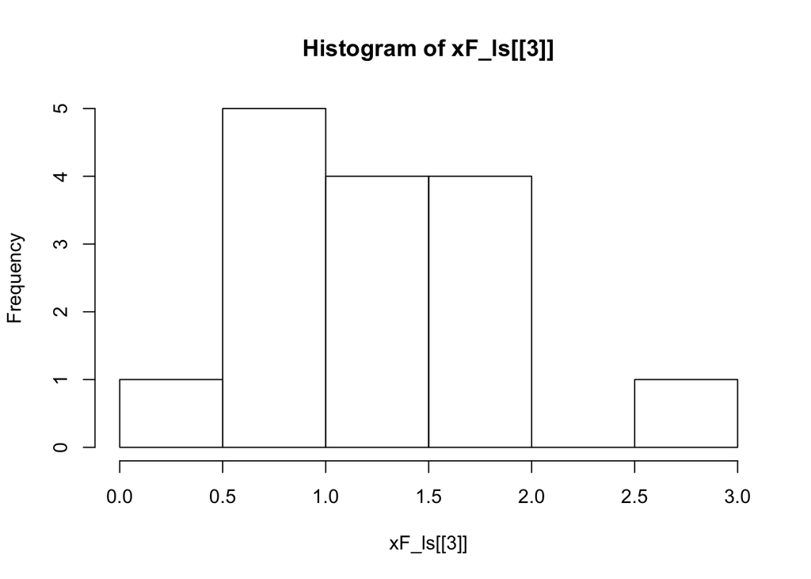

```r
set.seed(1234)
xF_ls <- list(
  distName = "F distribution",
  parameters = c(mean = 1.2, df1 = 90, df2 = 12),
  sample = rf(n = 15, df1 = 90, df2 = 12)
  )
xF_ls[["histogram"]] <- hist(xF_ls[[3]])
```

```r
ttest_F <- t.test(
  x = xF_ls$sample,
  alternative = "two.sided",
  mu = xF_ls[[2]][[1]]
)
ttest_F$statistic
```

```
##           t
## -0.09693846
```

```r
ttest_F$p.value
```

```
## [1] 0.9241493
```

```r
critVal_F <- qt(0.975, df = 15 - 1)
abs(ttest_F$statistic) > critVal_F
```

```
##     t
## FALSE
```

```r
xF_ls$pVal <- ttest_F$p.value
xF_ls$testStat <- ttest_F$statistic
xF_ls$critVal <- critVal_F
xF_ls$decision <- "Fail to Reject the Hypothesis that the True Mean Equals 1.2"
xF_ls
```

```
## $distName
## [1] "F distribution"
##
## $parameters
## mean  df1  df2
##  1.2 90.0 12.0
##
## $sample
##  [1] 0.7838245 1.5961089 1.5094300 1.6534040 2.5534175 0.7506925 1.0527880
##  [8] 1.6091905 1.3727835 1.0971313 0.8531488 0.8246397 0.4332778 0.5197757
## [15] 1.1846576
##
## $histogram
## $breaks
## [1] 0.0 0.5 1.0 1.5 2.0 2.5 3.0
##
## $counts
## [1] 1 5 4 4 0 1
##
## $density
## [1] 0.1333333 0.6666667 0.5333333 0.5333333 0.0000000 0.1333333
##
## $mids
## [1] 0.25 0.75 1.25 1.75 2.25 2.75
##
## $xname
## [1] "xF_ls[[3]]"
##
## $equidist
## [1] TRUE
##
## attr(,"class")
## [1] "histogram"
##
## $pVal
## [1] 0.9241493
##
## $testStat
##           t
## -0.09693846
##
## $critVal
## [1] 2.144787
##
## $decision
## [1] "Fail to Reject the Hypothesis that the True Mean Equals 1.2"
```

I failed to reject the hypothesis because the test statistic was not greater than the critical value.

#### Binomial Distribution:

$H_0: \mu = \mu_0;\quad H_A: \mu \ne \mu_0.$

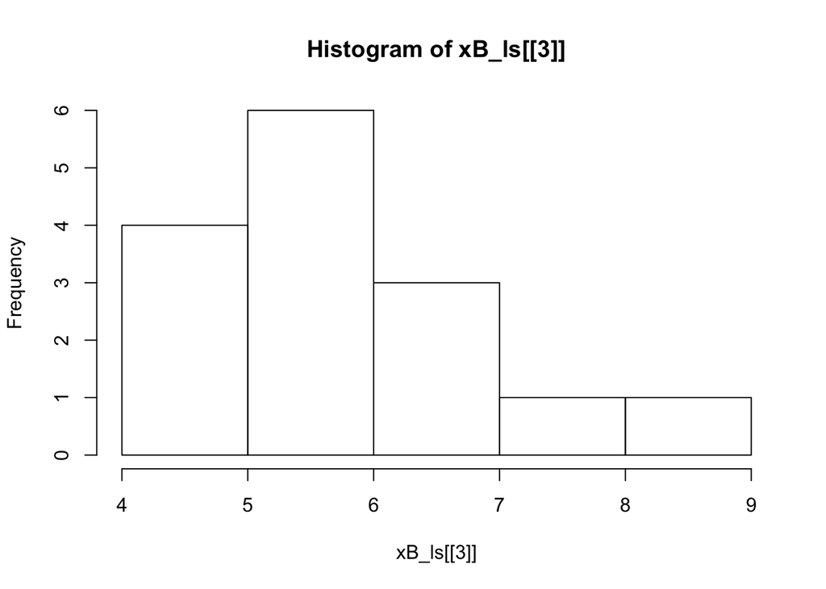

```r
set.seed(1234)
xB_ls <- list(
  distName = "Binomial distribution",
  parameters = c(mean = 6, size = 9, prob = (2/3)),
  sample = rbinom(n = 15, size = 9, prob = (2/3))
  )
xB_ls[["histogram"]] <- hist(xB_ls[[3]])
```

```r
ttest_B <- t.test(
  x = xB_ls$sample,
  alternative = "two.sided",
  mu = xB_ls[[2]][[1]]
)
ttest_B$statistic
```

```
##         t
## 0.3808907
```

```r
ttest_B$p.value
```

```
## [1] 0.7090018
```

```r
critVal_B <- qt(0.975, df = 15 - 1)
abs(ttest_B$statistic) > critVal_B
```

```
##     t
## FALSE
```

```r
xB_ls$pVal <- ttest_B$p.value
xB_ls$testStat <- ttest_B$statistic
xB_ls$critVal <- critVal_B
xB_ls$decision <- "Fail to Reject the Hypothesis that the True Mean Equals 6"
xB_ls
```

```
## $distName
## [1] "Binomial distribution"
##
## $parameters
##      mean      size      prob
## 6.0000000 9.0000000 0.6666667
##
## $sample
##  [1] 8 6 6 6 4 6 9 7 5 6 5 6 7 4 7
##
## $histogram
## $breaks
## [1] 4 5 6 7 8 9
##
## $counts
## [1] 4 6 3 1 1
##
## $density
## [1] 0.26666667 0.40000000 0.20000000 0.06666667 0.06666667
##
## $mids
## [1] 4.5 5.5 6.5 7.5 8.5
##
## $xname
## [1] "xB_ls[[3]]"
##
## $equidist
## [1] TRUE
##
## attr(,"class")
## [1] "histogram"
##
## $pVal
## [1] 0.7090018
##
## $testStat
##         t
## 0.3808907
##
## $critVal
## [1] 2.144787
##
## $decision
## [1] "Fail to Reject the Hypothesis that the True Mean Equals 6"
```

I failed to reject the hypothesis because the test statistic was not greater than the critical value.

#### Negative Binomial Distribution:

$H_0: \mu = \mu_0;\quad H_A: \mu \ne \mu_0.$

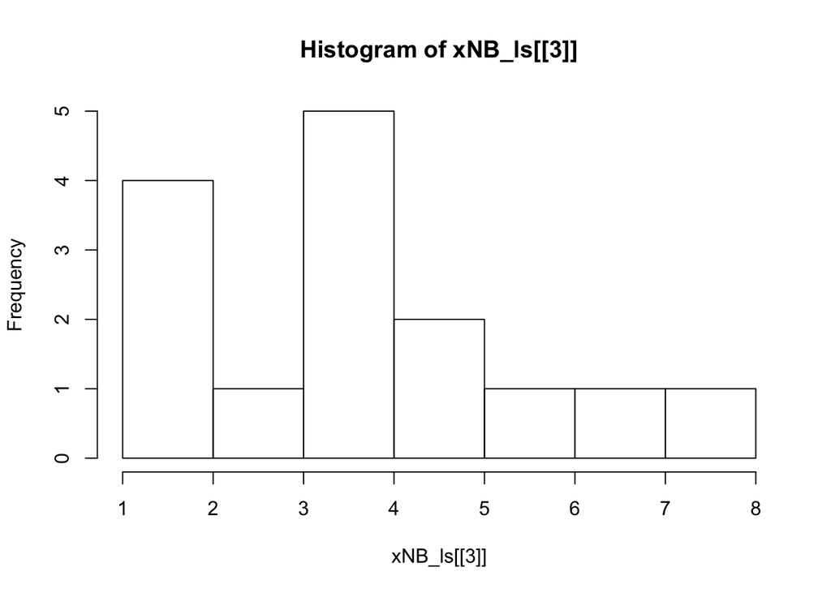

```r
set.seed(1234)
xNB_ls <- list(
  distName = "Negative Binomial distribution",
  parameters = c(mean = 5, size = 5, prob = 0.5),
  sample = rnbinom(n = 15, size = 5, prob = 0.5)
  )
xNB_ls[["histogram"]] <- hist(xNB_ls[[3]])
```

```r
ttest_NB <- t.test(
  x = xNB_ls$sample,
  alternative = "two.sided",
  mu = xNB_ls[[2]][[1]]
)
ttest_NB$statistic
```

```
##        t
## -1.85901
```

```r
ttest_NB$p.value
```

```
## [1] 0.08417192
```

```r
critVal_NB <- qt(0.975, df = 15 - 1)
abs(ttest_NB$statistic) > critVal_NB
```

```
##     t
## FALSE
```

```r
xNB_ls$pVal <- ttest_NB$p.value
xNB_ls$testStat <- ttest_NB$statistic
xNB_ls$critVal <- critVal_NB
xNB_ls$decision <- "Fail to Reject the Hypothesis that the True Mean Equals 5"
xNB_ls
```

```
## $distName
## [1] "Negative Binomial distribution"
##
## $parameters
## mean size prob
##  5.0  5.0  0.5
##
## $sample
##  [1] 3 2 4 8 2 2 4 7 1 6 4 4 5 4 5
##
## $histogram
## $breaks
## [1] 1 2 3 4 5 6 7 8
##
## $counts
## [1] 4 1 5 2 1 1 1
##
## $density
## [1] 0.26666667 0.06666667 0.33333333 0.13333333 0.06666667 0.06666667
## [7] 0.06666667
##
## $mids
## [1] 1.5 2.5 3.5 4.5 5.5 6.5 7.5
##
## $xname
## [1] "xNB_ls[[3]]"
##
## $equidist
## [1] TRUE
##
## attr(,"class")
## [1] "histogram"
##
## $pVal
## [1] 0.08417192
##
## $testStat
##        t
## -1.85901
##
## $critVal
## [1] 2.144787
##
## $decision
## [1] "Fail to Reject the Hypothesis that the True Mean Equals 5"
```

I failed to reject the hypothesis because the test statistic was not greater than the critical value.

#### Poisson Distribution:

$H_0: \mu = \mu_0;\quad H_A: \mu \ne \mu_0.$

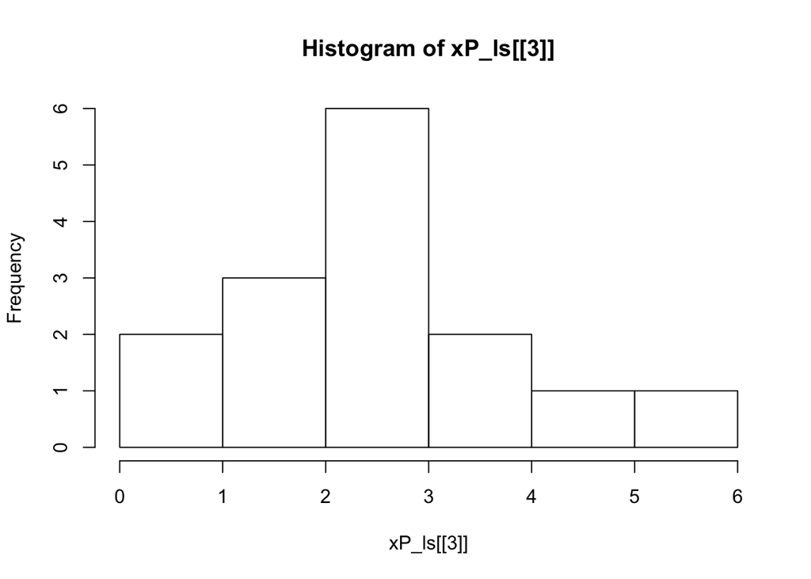

```r
set.seed(1234)
xP_ls <- list(
  distName = "Poisson distribution",
  parameters = c(lambda = 3),
  sample = rpois(n = 15, lambda = 3)
  )
xP_ls[["histogram"]] <- hist(xP_ls[[3]])
```

```r
ttest_P <- t.test(
  x = xP_ls$sample,
  alternative = "two.sided",
  mu = xP_ls[[2]][[1]]
)
ttest_P$statistic
```

```
##          t
## -0.1737021
```

```r
ttest_P$p.value
```

```
## [1] 0.8645862
```

```r
critVal_P <- qt(0.975, df = 15 - 1)
abs(ttest_P$statistic) > critVal_P
```

```
##     t
## FALSE
```

```r
xP_ls$pVal <- ttest_P$p.value
xP_ls$testStat <- ttest_P$statistic
xP_ls$critVal <- critVal_P
xP_ls$decision <- "Fail to Reject the Hypothesis that the True Mean Equals 3"
xP_ls
```

```
## $distName
## [1] "Poisson distribution"
##
## $parameters
## lambda
##      3
##
## $sample
##  [1] 1 3 3 3 5 3 0 2 4 3 4 3 2 6 2
##
## $histogram
## $breaks
## [1] 0 1 2 3 4 5 6
##
## $counts
## [1] 2 3 6 2 1 1
##
## $density
## [1] 0.13333333 0.20000000 0.40000000 0.13333333 0.06666667 0.06666667
##
## $mids
## [1] 0.5 1.5 2.5 3.5 4.5 5.5
##
## $xname
## [1] "xP_ls[[3]]"
##
## $equidist
## [1] TRUE
##
## attr(,"class")
## [1] "histogram"
##
## $pVal
## [1] 0.8645862
##
## $testStat
##          t
## -0.1737021
##
## $critVal
## [1] 2.144787
##
## $decision
## [1] "Fail to Reject the Hypothesis that the True Mean Equals 3"
```

I failed to reject the hypothesis because the test statistic was not greater than the critical value.